# R Markdown Tutorial - Lessons from DataCamp Course

Aishameriane Schmidt

14 de novembro de 2016

# Authoring R Markdown Reports

## Introduction

R Markdown is a tool for reporting your results with R. It brings together the best ideas from literate programming, dynamic documents and reproducible research. With R Markdown you suplement your R code with interaction to come with a complete report. It’s easy to update and work with code in this form, because it is all still there. Whe you are ready to deliver your results, R Markdown uses your code to produce a final report, which can be an HTML entry, a PDF paper, a Microsoft Word file or a slideshow. R Markdown can build each format from your code, which means you can distribute your work in multiple ways. And if your data ever changes, you can just re-run your code to build a new report.

To see how it looks like in real life, see the image below, which contains a R Markdown file coded in R Studio IDE.

[figure not shown]

Interface

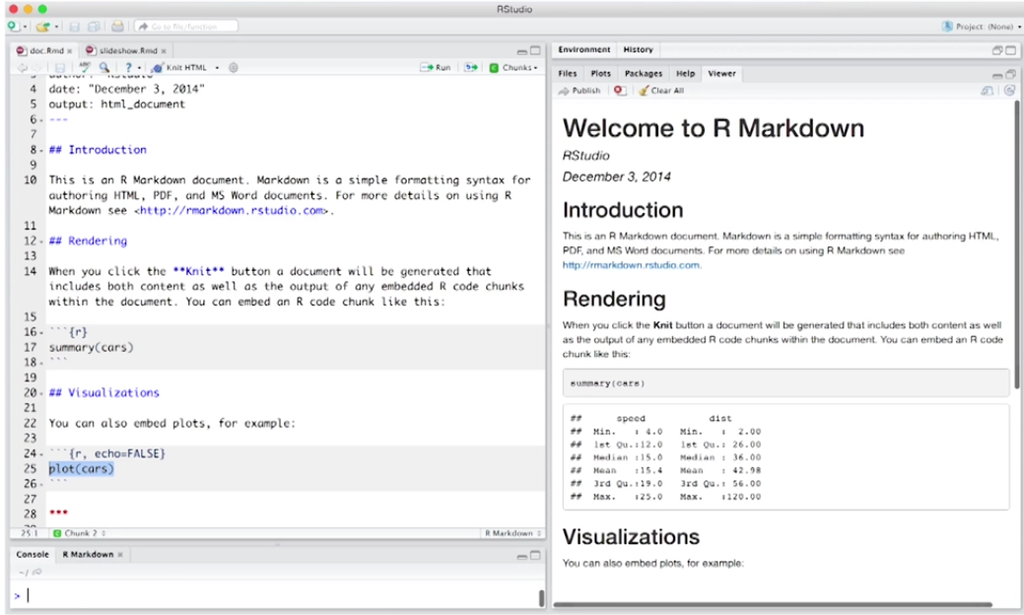

You can try to knit in other formats, like PDF:

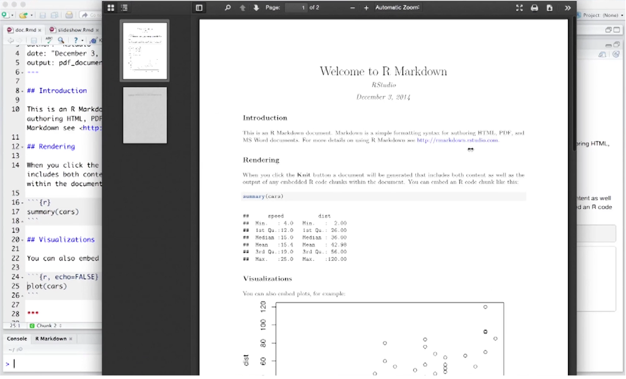

PDF compiled from code

HTML:

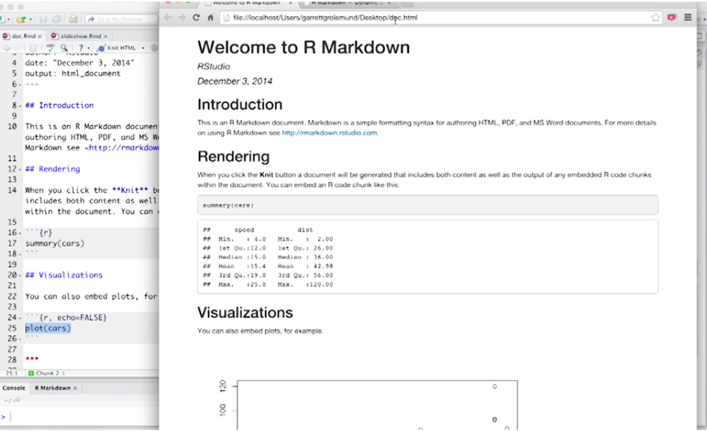

HTML page compiled from code

Microsoft Word:

[figure not shown]

Or even a slideshow:

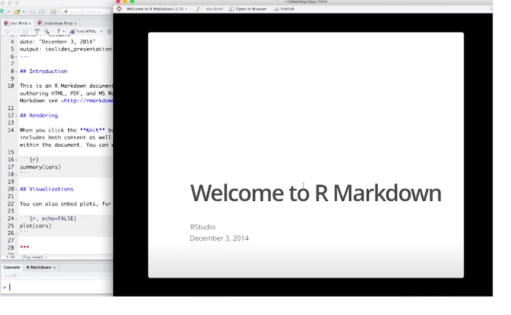

Slides compiled from code

When you compile your document, R Markdown will run your chunks of R presents in you code and add the results in the final output. This creates an ideal format for your reproducible research. Use R code to create numbers, tables and figures for your report. Your report will contain all the code needed to reproduce your result, the interation in your code will make it easier to understand. And if you find a mistake or if your data ever changes, you can easily re-render your file to create an updated report.

R Markdown reports are very versitile, you can add multiple types of code, not just R. And you can add elements from the Shiny package to create interactive output, like an interactive slideshow.

**Example 1**